# MPRAsnakeflow assignment QC report

# Overview

The Assignment QC (Quality Control) Report is a comprehensive document designed to evaluate and ensure the quality of data or processes involved in a specific assignment. This report is generated for the GSE325256 assignment with settings defined in the config default. The barcode length for this experiment is 15 bases.

- **Forward:** data/assignment/SRR37895574_1.fastq.gz
- **Reverse:** data/assignment/SRR37895574_3.fastq.gz
- **Barcode:** data/assignment/SRR37895574_2.fastq.gz
- **Design File:** data/assignment/GSM9640449_VariantMPRAdesignFile.seq_merged.fa

# Overall quality metrics

**Table explanation**

- **median assigned barcodes:** Median number of barcodes assigned to tested sequences in mapping as a quality control measure for the assignment step, whether there is sufficient barcode to oligo coverage.
- **fraction assigned oligos:** Fraction of assigned tested sequences in mapping to determine if the library during the assignment step was sufficiently recovered.

| median assigned barcodes | fraction assigned oligos |
| --- | --- |
| 878 | 0.69 |

# BC distribution over oligos

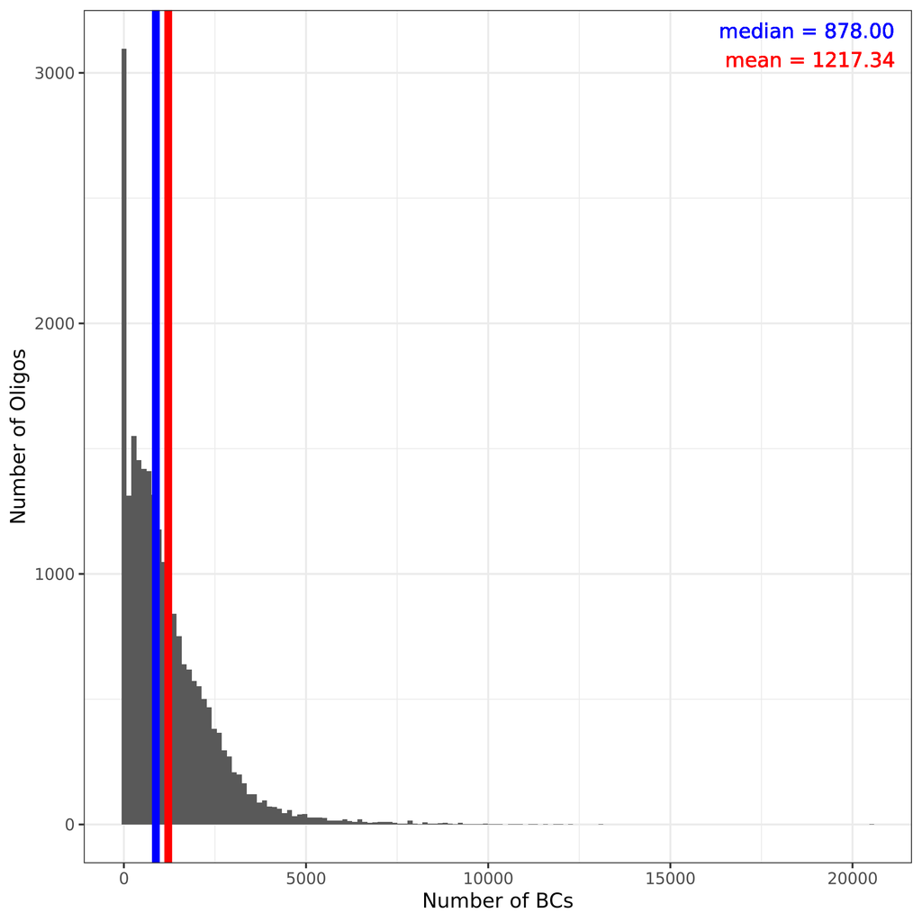

# Counts of barcodes and oligos

**Table explanation**

- **BCs** are the different observed barcodes in the sequencing data (not the overall barcode count/number of BC reads).
- Differences in row `BCs` between `Raw data` and `Filtered data` are due to barcodes that do not match the length of 15 bases defined in the default config of the config file.
- **Other BCs** are those barcodes where no oligo could be assigned due to mapping (e.g., due to MAPQ filter or due to multiple matches).
- **Ambiguous BCs** are those that map to a designed oligo but failed the minimum required barcodes per oligo of 3 and/or the minimum required fraction of 0.75 assigned to one unique oligo.

|  | Design | Raw data | Filtered data |
| --- | --- | --- | --- |
| Oligos | 32889 | 25925 | 22779 |
| BCs | 0 | 86143661 | 86143661 |
| Assigned BCs | 0 | 0 | 27729887 |
| Other BCs | 0 | 0 | 26027739 |
| Ambiguous BCs | 0 | 0 | 32386035 |